# Análisis Exploratorio de Datos (EDA)

#### Cash Reinvestment %

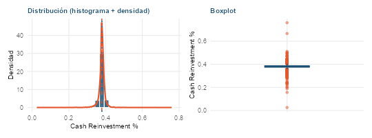

El histograma de **Cash Reinvestment %** muestra un marcado sesgo a la izquierda (asimetría negativa), con una media de **0.3796** y una mediana de **0.3803**. La curtosis observada de **72.47** indica la concentración de observaciones alrededor de la zona central, con posibles valores atípicos en las colas. Esta morfología sugiere una alta homogeneidad en el grueso de las empresas analizadas, con comportamientos extremos puntuales a monitorear en el preprocesamiento.

#### Current Ratio

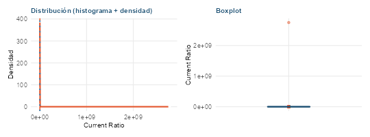

El histograma de **Current Ratio** muestra un marcado sesgo a la derecha (asimetría positiva), con una media de **504032.2733** y una mediana de **0.0106**. La curtosis observada de **5456.00** indica la concentración de observaciones alrededor de la zona central, con posibles valores atípicos en las colas. Esta morfología sugiere una alta homogeneidad en el grueso de las empresas analizadas, con comportamientos extremos puntuales a monitorear en el preprocesamiento.

#### Quick Ratio

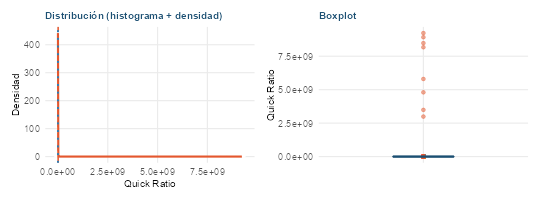

El histograma de **Quick Ratio** muestra un marcado sesgo a la derecha (asimetría positiva), con una media de **9508797.6651** y una mediana de **0.0074**. La curtosis observada de **938.53** indica la concentración de observaciones alrededor de la zona central, con posibles valores atípicos en las colas. Esta morfología sugiere una alta homogeneidad en el grueso de las empresas analizadas, con comportamientos extremos puntuales a monitorear en el preprocesamiento.

#### Interest Expense Ratio

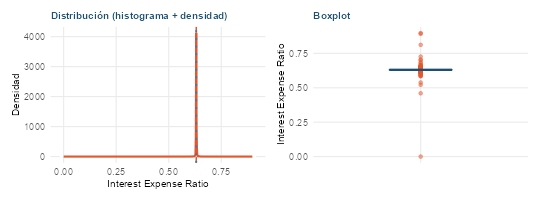

El histograma de **Interest Expense Ratio** muestra un marcado sesgo a la izquierda (asimetría negativa), con una media de **0.6310** y una mediana de **0.6307**. La curtosis observada de **1974.83** indica la concentración de observaciones alrededor de la zona central, con posibles valores atípicos en las colas. Esta morfología sugiere una alta homogeneidad en el grueso de las empresas analizadas, con comportamientos extremos puntuales a monitorear en el preprocesamiento.

#### Total debt/Total net worth

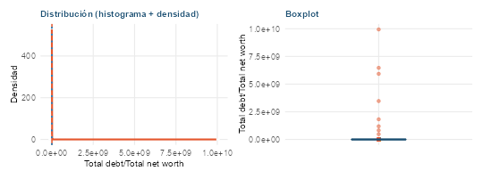

El histograma de **Total debt/Total net worth** muestra un marcado sesgo a la derecha (asimetría positiva), con una media de **5519611.4450** y una mediana de **0.0055**. La curtosis observada de **1878.29** indica la concentración de observaciones alrededor de la zona central, con posibles valores atípicos en las colas. Esta morfología sugiere una alta homogeneidad en el grueso de las empresas analizadas, con comportamientos extremos puntuales a monitorear en el preprocesamiento.

#### Debt ratio %

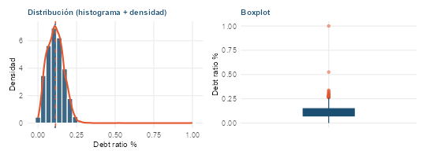

El histograma de **Debt ratio %** muestra un marcado sesgo a la derecha (asimetría positiva), con una media de **0.1135** y una mediana de **0.1112**. La curtosis observada de **13.04** indica la concentración de observaciones alrededor de la zona central, con posibles valores atípicos en las colas. Esta morfología sugiere una alta homogeneidad en el grueso de las empresas analizadas, con comportamientos extremos puntuales a monitorear en el preprocesamiento.

#### Net worth/Assets

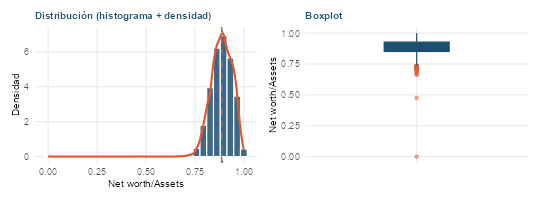

El histograma de **Net worth/Assets** muestra un marcado sesgo a la izquierda (asimetría negativa), con una media de **0.8865** y una mediana de **0.8888**. La curtosis observada de **13.04** indica la concentración de observaciones alrededor de la zona central, con posibles valores atípicos en las colas. Esta morfología sugiere una alta homogeneidad en el grueso de las empresas analizadas, con comportamientos extremos puntuales a monitorear en el preprocesamiento.

#### Long-term fund suitability ratio (A)

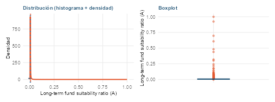

El histograma de **Long-term fund suitability ratio (A)** muestra un marcado sesgo a la derecha (asimetría positiva), con una media de **0.0085** y una mediana de **0.0056**. La curtosis observada de **848.01** indica la concentración de observaciones alrededor de la zona central, con posibles valores atípicos en las colas. Esta morfología sugiere una alta homogeneidad en el grueso de las empresas analizadas, con comportamientos extremos puntuales a monitorear en el preprocesamiento.

#### Borrowing dependency

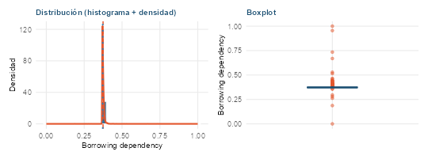

El histograma de **Borrowing dependency** muestra un marcado sesgo a la derecha (asimetría positiva), con una media de **0.3746** y una mediana de **0.3726**. La curtosis observada de **853.16** indica la concentración de observaciones alrededor de la zona central, con posibles valores atípicos en las colas. Esta morfología sugiere una alta homogeneidad en el grueso de las empresas analizadas, con comportamientos extremos puntuales a monitorear en el preprocesamiento.

#### Contingent liabilities/Net worth

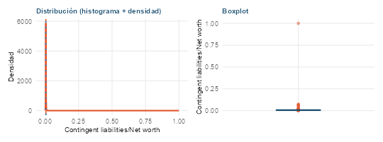

El histograma de **Contingent liabilities/Net worth** muestra un marcado sesgo a la derecha (asimetría positiva), con una media de **0.0060** y una mediana de **0.0054**. La curtosis observada de **5214.29** indica la concentración de observaciones alrededor de la zona central, con posibles valores atípicos en las colas. Esta morfología sugiere una alta homogeneidad en el grueso de las empresas analizadas, con comportamientos extremos puntuales a monitorear en el preprocesamiento.

#### Operating profit/Paid-in capital

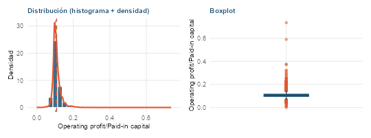

El histograma de **Operating profit/Paid-in capital** muestra un marcado sesgo a la derecha (asimetría positiva), con una media de **0.1088** y una mediana de **0.1042**. La curtosis observada de **94.53** indica la concentración de observaciones alrededor de la zona central, con posibles valores atípicos en las colas. Esta morfología sugiere una alta homogeneidad en el grueso de las empresas analizadas, con comportamientos extremos puntuales a monitorear en el preprocesamiento.

#### Net profit before tax/Paid-in capital

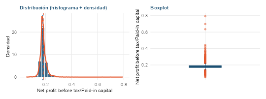

El histograma de **Net profit before tax/Paid-in capital** muestra un marcado sesgo a la derecha (asimetría positiva), con una media de **0.1825** y una mediana de **0.1786**. La curtosis observada de **69.94** indica la concentración de observaciones alrededor de la zona central, con posibles valores atípicos en las colas. Esta morfología sugiere una alta homogeneidad en el grueso de las empresas analizadas, con comportamientos extremos puntuales a monitorear en el preprocesamiento.

#### Inventory and accounts receivable/Net value

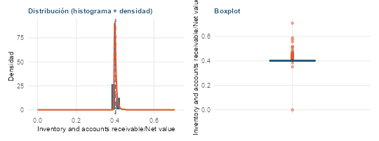

El histograma de **Inventory and accounts receivable/Net value** muestra un marcado sesgo a la izquierda (asimetría negativa), con una media de **0.4024** y una mediana de **0.4001**. La curtosis observada de **388.75** indica la concentración de observaciones alrededor de la zona central, con posibles valores atípicos en las colas. Esta morfología sugiere una alta homogeneidad en el grueso de las empresas analizadas, con comportamientos extremos puntuales a monitorear en el preprocesamiento.

#### Total Asset Turnover

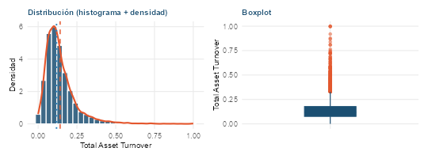

El histograma de **Total Asset Turnover** muestra un marcado sesgo a la derecha (asimetría positiva), con una media de **0.1418** y una mediana de **0.1184**. La curtosis observada de **9.63** indica la concentración de observaciones alrededor de la zona central, con posibles valores atípicos en las colas. Esta morfología sugiere una alta homogeneidad en el grueso de las empresas analizadas, con comportamientos extremos puntuales a monitorear en el preprocesamiento.

#### Accounts Receivable Turnover

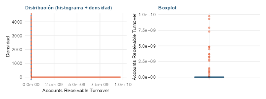

El histograma de **Accounts Receivable Turnover** muestra un marcado sesgo a la derecha (asimetría positiva), con una media de **13401576.2485** y una mediana de **0.0010**. La curtosis observada de **737.92** indica la concentración de observaciones alrededor de la zona central, con posibles valores atípicos en las colas. Esta morfología sugiere una alta homogeneidad en el grueso de las empresas analizadas, con comportamientos extremos puntuales a monitorear en el preprocesamiento.

#### Average Collection Days

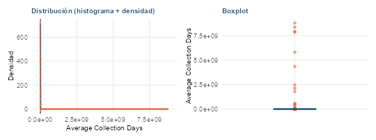

El histograma de **Average Collection Days** muestra un marcado sesgo a la derecha (asimetría positiva), con una media de **9438049.8612** y una mediana de **0.0066**. La curtosis observada de **953.52** indica la concentración de observaciones alrededor de la zona central, con posibles valores atípicos en las colas. Esta morfología sugiere una alta homogeneidad en el grueso de las empresas analizadas, con comportamientos extremos puntuales a monitorear en el preprocesamiento.

#### Inventory Turnover Rate (times)

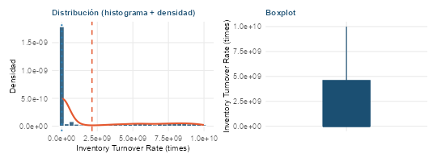

#### Fixed Assets Turnover Frequency

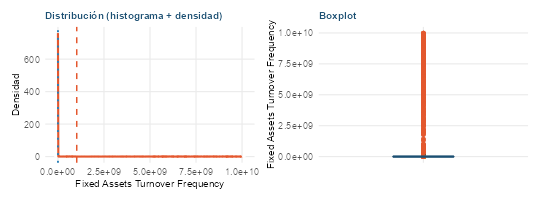

El histograma de **Fixed Assets Turnover Frequency** muestra un marcado sesgo a la derecha (asimetría positiva), con una media de **1020131744.8699** y una mediana de **0.0006**. La curtosis observada de **3.98** indica la concentración de observaciones alrededor de la zona central, con posibles valores atípicos en las colas. Esta morfología sugiere una alta homogeneidad en el grueso de las empresas analizadas, con comportamientos extremos puntuales a monitorear en el preprocesamiento.

#### Net Worth Turnover Rate (times)

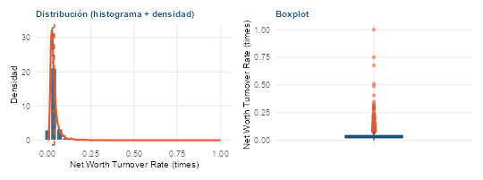

El histograma de **Net Worth Turnover Rate (times)** muestra un marcado sesgo a la derecha (asimetría positiva), con una media de **0.0386** y una mediana de **0.0295**. La curtosis observada de **153.88** indica la concentración de observaciones alrededor de la zona central, con posibles valores atípicos en las colas. Esta morfología sugiere una alta homogeneidad en el grueso de las empresas analizadas, con comportamientos extremos puntuales a monitorear en el preprocesamiento.

#### Revenue per person

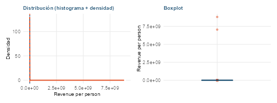

El histograma de **Revenue per person** muestra un marcado sesgo a la derecha (asimetría positiva), con una media de **2906891.5313** y una mediana de **0.0186**. La curtosis observada de **2856.77** indica la concentración de observaciones alrededor de la zona central, con posibles valores atípicos en las colas. Esta morfología sugiere una alta homogeneidad en el grueso de las empresas analizadas, con comportamientos extremos puntuales a monitorear en el preprocesamiento.

#### Operating profit per person

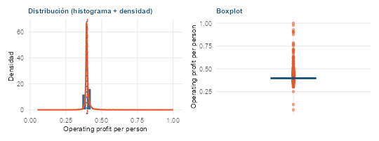

El histograma de **Operating profit per person** muestra un marcado sesgo a la derecha (asimetría positiva), con una media de **0.4007** y una mediana de **0.3959**. La curtosis observada de **120.00** indica la concentración de observaciones alrededor de la zona central, con posibles valores atípicos en las colas. Esta morfología sugiere una alta homogeneidad en el grueso de las empresas analizadas, con comportamientos extremos puntuales a monitorear en el preprocesamiento.

#### Allocation rate per person

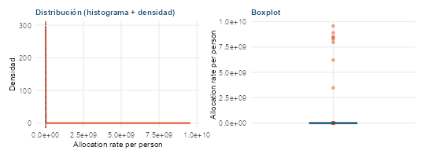

El histograma de **Allocation rate per person** muestra un marcado sesgo a la derecha (asimetría positiva), con una media de **11242668.6376** y una mediana de **0.0079**. La curtosis observada de **775.95** indica la concentración de observaciones alrededor de la zona central, con posibles valores atípicos en las colas. Esta morfología sugiere una alta homogeneidad en el grueso de las empresas analizadas, con comportamientos extremos puntuales a monitorear en el preprocesamiento.

#### Working Capital to Total Assets

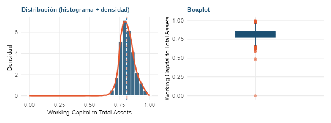

El histograma de **Working Capital to Total Assets** muestra una distribución relativamente simétrica, con una media de **0.8137** y una mediana de **0.8093**. La curtosis observada de **6.62** indica la concentración de observaciones alrededor de la zona central, con posibles valores atípicos en las colas. Esta morfología sugiere una alta homogeneidad en el grueso de las empresas analizadas, con comportamientos extremos puntuales a monitorear en el preprocesamiento.

#### Quick Assets/Total Assets

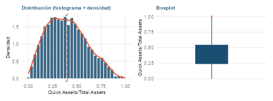

#### Current Assets/Total Assets

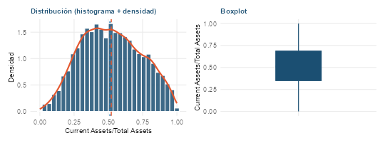

#### Cash/Total Assets

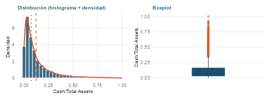

El histograma de **Cash/Total Assets** muestra un marcado sesgo a la derecha (asimetría positiva), con una media de **0.1231** y una mediana de **0.0734**. La curtosis observada de **5.99** indica la concentración de observaciones alrededor de la zona central, con posibles valores atípicos en las colas. Esta morfología sugiere una alta homogeneidad en el grueso de las empresas analizadas, con comportamientos extremos puntuales a monitorear en el preprocesamiento.

#### Quick Assets/Current Liability

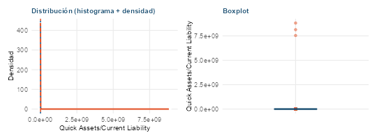

El histograma de **Quick Assets/Current Liability** muestra un marcado sesgo a la derecha (asimetría positiva), con una media de **4490469.2200** y una mediana de **0.0079**. La curtosis observada de **1845.11** indica la concentración de observaciones alrededor de la zona central, con posibles valores atípicos en las colas. Esta morfología sugiere una alta homogeneidad en el grueso de las empresas analizadas, con comportamientos extremos puntuales a monitorear en el preprocesamiento.

#### Cash/Current Liability

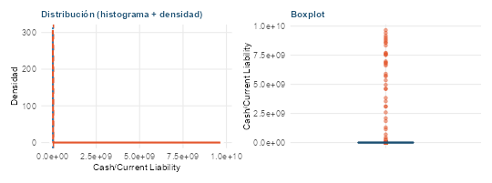

El histograma de **Cash/Current Liability** muestra un marcado sesgo a la derecha (asimetría positiva), con una media de **39106488.2830** y una mediana de **0.0048**. La curtosis observada de **217.59** indica la concentración de observaciones alrededor de la zona central, con posibles valores atípicos en las colas. Esta morfología sugiere una alta homogeneidad en el grueso de las empresas analizadas, con comportamientos extremos puntuales a monitorear en el preprocesamiento.

#### Current Liability to Assets

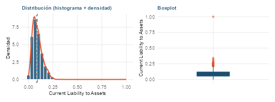

El histograma de **Current Liability to Assets** muestra un marcado sesgo a la derecha (asimetría positiva), con una media de **0.0908** y una mediana de **0.0823**. La curtosis observada de **18.91** indica la concentración de observaciones alrededor de la zona central, con posibles valores atípicos en las colas. Esta morfología sugiere una alta homogeneidad en el grueso de las empresas analizadas, con comportamientos extremos puntuales a monitorear en el preprocesamiento.

#### Operating Funds to Liability

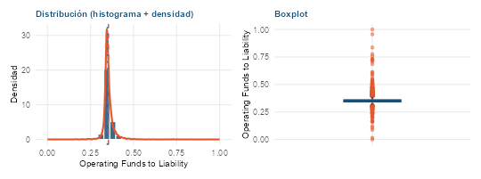

El histograma de **Operating Funds to Liability** muestra un marcado sesgo a la derecha (asimetría positiva), con una media de **0.3539** y una mediana de **0.3485**. La curtosis observada de **65.46** indica la concentración de observaciones alrededor de la zona central, con posibles valores atípicos en las colas. Esta morfología sugiere una alta homogeneidad en el grueso de las empresas analizadas, con comportamientos extremos puntuales a monitorear en el preprocesamiento.

#### Inventory/Working Capital

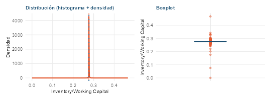

El histograma de **Inventory/Working Capital** muestra un marcado sesgo a la izquierda (asimetría negativa), con una media de **0.2773** y una mediana de **0.2772**. La curtosis observada de **1139.25** indica la concentración de observaciones alrededor de la zona central, con posibles valores atípicos en las colas. Esta morfología sugiere una alta homogeneidad en el grueso de las empresas analizadas, con comportamientos extremos puntuales a monitorear en el preprocesamiento.

#### Inventory/Current Liability

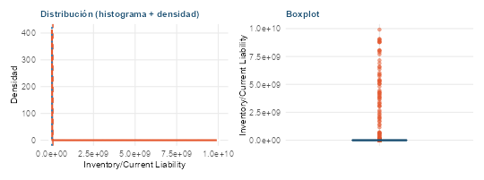

El histograma de **Inventory/Current Liability** muestra un marcado sesgo a la derecha (asimetría positiva), con una media de **57918859.9798** y una mediana de **0.0065**. La curtosis observada de **147.33** indica la concentración de observaciones alrededor de la zona central, con posibles valores atípicos en las colas. Esta morfología sugiere una alta homogeneidad en el grueso de las empresas analizadas, con comportamientos extremos puntuales a monitorear en el preprocesamiento.

#### Current Liabilities/Liability

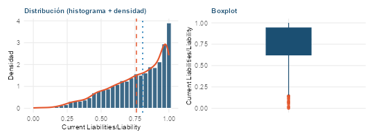

#### Working Capital/Equity

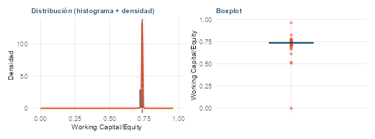

El histograma de **Working Capital/Equity** muestra un marcado sesgo a la izquierda (asimetría negativa), con una media de **0.7357** y una mediana de **0.7360**. La curtosis observada de **2434.02** indica la concentración de observaciones alrededor de la zona central, con posibles valores atípicos en las colas. Esta morfología sugiere una alta homogeneidad en el grueso de las empresas analizadas, con comportamientos extremos puntuales a monitorear en el preprocesamiento.

#### Current Liabilities/Equity

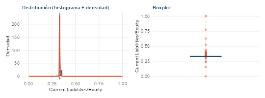

El histograma de **Current Liabilities/Equity** muestra un marcado sesgo a la derecha (asimetría positiva), con una media de **0.3314** y una mediana de **0.3297**. La curtosis observada de **1133.32** indica la concentración de observaciones alrededor de la zona central, con posibles valores atípicos en las colas. Esta morfología sugiere una alta homogeneidad en el grueso de las empresas analizadas, con comportamientos extremos puntuales a monitorear en el preprocesamiento.

#### Long-term Liability to Current Assets

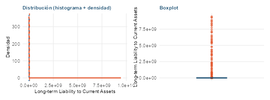

El histograma de **Long-term Liability to Current Assets** muestra un marcado sesgo a la derecha (asimetría positiva), con una media de **54330315.2566** y una mediana de **0.0020**. La curtosis observada de **160.99** indica la concentración de observaciones alrededor de la zona central, con posibles valores atípicos en las colas. Esta morfología sugiere una alta homogeneidad en el grueso de las empresas analizadas, con comportamientos extremos puntuales a monitorear en el preprocesamiento.

#### Retained Earnings to Total Assets

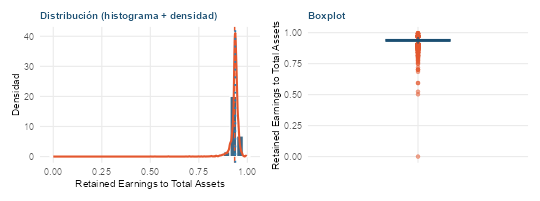

El histograma de **Retained Earnings to Total Assets** muestra un marcado sesgo a la izquierda (asimetría negativa), con una media de **0.9346** y una mediana de **0.9377**. La curtosis observada de **329.01** indica la concentración de observaciones alrededor de la zona central, con posibles valores atípicos en las colas. Esta morfología sugiere una alta homogeneidad en el grueso de las empresas analizadas, con comportamientos extremos puntuales a monitorear en el preprocesamiento.

#### Total income/Total expense

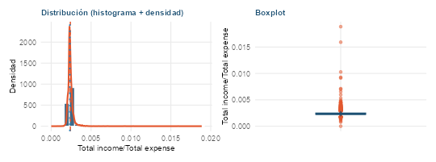

El histograma de **Total income/Total expense** muestra un marcado sesgo a la derecha (asimetría positiva), con una media de **0.0024** y una mediana de **0.0023**. La curtosis observada de **430.51** indica la concentración de observaciones alrededor de la zona central, con posibles valores atípicos en las colas. Esta morfología sugiere una alta homogeneidad en el grueso de las empresas analizadas, con comportamientos extremos puntuales a monitorear en el preprocesamiento.

#### Total expense/Assets

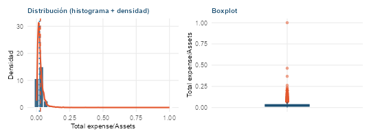

El histograma de **Total expense/Assets** muestra un marcado sesgo a la derecha (asimetría positiva), con una media de **0.0293** y una mediana de **0.0227**. La curtosis observada de **278.58** indica la concentración de observaciones alrededor de la zona central, con posibles valores atípicos en las colas. Esta morfología sugiere una alta homogeneidad en el grueso de las empresas analizadas, con comportamientos extremos puntuales a monitorear en el preprocesamiento.

#### Current Asset Turnover Rate

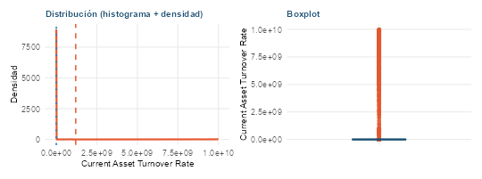

El histograma de **Current Asset Turnover Rate** muestra un marcado sesgo a la derecha (asimetría positiva), con una media de **1195283187.3171** y una mediana de **0.0002**. La curtosis observada de **2.80** indica la concentración de observaciones alrededor de la zona central, con posibles valores atípicos en las colas. Esta morfología sugiere una alta homogeneidad en el grueso de las empresas analizadas, con comportamientos extremos puntuales a monitorear en el preprocesamiento.

#### Quick Asset Turnover Rate

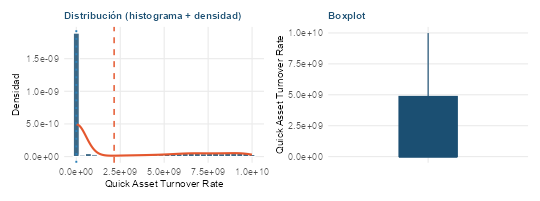

El histograma de **Quick Asset Turnover Rate** muestra un marcado sesgo a la derecha (asimetría positiva), con una media de **2150333284.4578** y una mediana de **0.0002**. La curtosis observada de **-0.37** indica la concentración de observaciones alrededor de la zona central, con posibles valores atípicos en las colas. Esta morfología sugiere una alta homogeneidad en el grueso de las empresas analizadas, con comportamientos extremos puntuales a monitorear en el preprocesamiento.

#### Working capitcal Turnover Rate

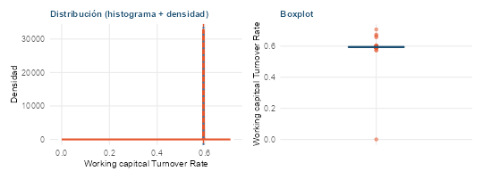

El histograma de **Working capitcal Turnover Rate** muestra un marcado sesgo a la izquierda (asimetría negativa), con una media de **0.5939** y una mediana de **0.5940**. La curtosis observada de **4654.13** indica la concentración de observaciones alrededor de la zona central, con posibles valores atípicos en las colas. Esta morfología sugiere una alta homogeneidad en el grueso de las empresas analizadas, con comportamientos extremos puntuales a monitorear en el preprocesamiento.

#### Cash Turnover Rate

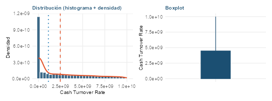

El histograma de **Cash Turnover Rate** muestra un marcado sesgo a la derecha (asimetría positiva), con una media de **2465869105.7554** y una mediana de **1130000000.0000**. La curtosis observada de **-0.35** indica la concentración de observaciones alrededor de la zona central, con posibles valores atípicos en las colas. Esta morfología sugiere una alta homogeneidad en el grueso de las empresas analizadas, con comportamientos extremos puntuales a monitorear en el preprocesamiento.

#### Cash Flow to Sales

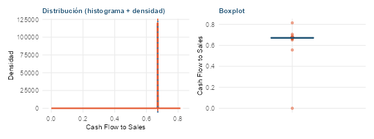

El histograma de **Cash Flow to Sales** muestra un marcado sesgo a la izquierda (asimetría negativa), con una media de **0.6715** y una mediana de **0.6716**. La curtosis observada de **4691.82** indica la concentración de observaciones alrededor de la zona central, con posibles valores atípicos en las colas. Esta morfología sugiere una alta homogeneidad en el grueso de las empresas analizadas, con comportamientos extremos puntuales a monitorear en el preprocesamiento.

#### Fixed Assets to Assets

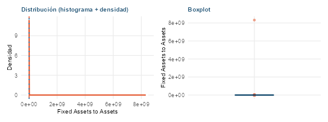

El histograma de **Fixed Assets to Assets** muestra un marcado sesgo a la derecha (asimetría positiva), con una media de **1524926.9381** y una mediana de **0.1994**. La curtosis observada de **5456.00** indica la concentración de observaciones alrededor de la zona central, con posibles valores atípicos en las colas. Esta morfología sugiere una alta homogeneidad en el grueso de las empresas analizadas, con comportamientos extremos puntuales a monitorear en el preprocesamiento.

#### Current Liability to Liability

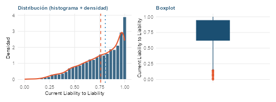

El histograma de **Current Liability to Liability** muestra un marcado sesgo a la izquierda (asimetría negativa), con una media de **0.7607** y una mediana de **0.8068**. La curtosis observada de **-0.02** indica la concentración de observaciones alrededor de la zona central, con posibles valores atípicos en las colas. Esta morfología sugiere una alta homogeneidad en el grueso de las empresas analizadas, con comportamientos extremos puntuales a monitorear en el preprocesamiento.

#### Current Liability to Equity

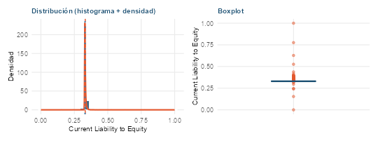

El histograma de **Current Liability to Equity** muestra un marcado sesgo a la derecha (asimetría positiva), con una media de **0.3314** y una mediana de **0.3297**. La curtosis observada de **1133.32** indica la concentración de observaciones alrededor de la zona central, con posibles valores atípicos en las colas. Esta morfología sugiere una alta homogeneidad en el grueso de las empresas analizadas, con comportamientos extremos puntuales a monitorear en el preprocesamiento.

#### Equity to Long-term Liability

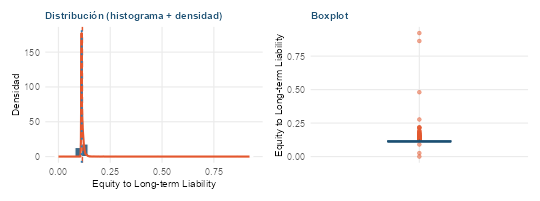

El histograma de **Equity to Long-term Liability** muestra un marcado sesgo a la derecha (asimetría positiva), con una media de **0.1156** y una mediana de **0.1124**. La curtosis observada de **1463.64** indica la concentración de observaciones alrededor de la zona central, con posibles valores atípicos en las colas. Esta morfología sugiere una alta homogeneidad en el grueso de las empresas analizadas, con comportamientos extremos puntuales a monitorear en el preprocesamiento.

#### Cash Flow to Total Assets

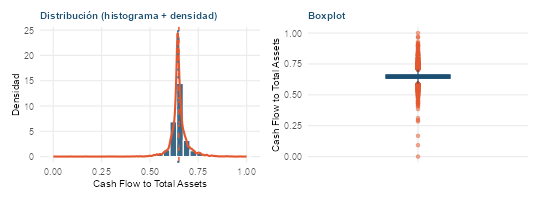

El histograma de **Cash Flow to Total Assets** muestra una distribución relativamente simétrica, con una media de **0.6494** y una mediana de **0.6452**. La curtosis observada de **18.50** indica la concentración de observaciones alrededor de la zona central, con posibles valores atípicos en las colas. Esta morfología sugiere una alta homogeneidad en el grueso de las empresas analizadas, con comportamientos extremos puntuales a monitorear en el preprocesamiento.

#### Cash Flow to Liability

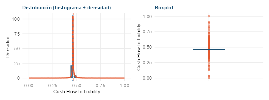

El histograma de **Cash Flow to Liability** muestra un marcado sesgo a la derecha (asimetría positiva), con una media de **0.4619** y una mediana de **0.4597**. La curtosis observada de **83.50** indica la concentración de observaciones alrededor de la zona central, con posibles valores atípicos en las colas. Esta morfología sugiere una alta homogeneidad en el grueso de las empresas analizadas, con comportamientos extremos puntuales a monitorear en el preprocesamiento.

#### CFO to Assets

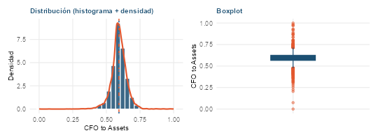

El histograma de **CFO to Assets** muestra una distribución relativamente simétrica, con una media de **0.5934** y una mediana de **0.5932**. La curtosis observada de **7.47** indica la concentración de observaciones alrededor de la zona central, con posibles valores atípicos en las colas. Esta morfología sugiere una alta homogeneidad en el grueso de las empresas analizadas, con comportamientos extremos puntuales a monitorear en el preprocesamiento.

#### Cash Flow to Equity

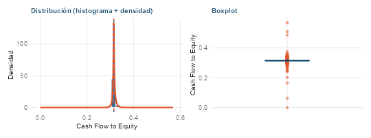

El histograma de **Cash Flow to Equity** muestra un marcado sesgo a la izquierda (asimetría negativa), con una media de **0.3154** y una mediana de **0.3149**. La curtosis observada de **314.78** indica la concentración de observaciones alrededor de la zona central, con posibles valores atípicos en las colas. Esta morfología sugiere una alta homogeneidad en el grueso de las empresas analizadas, con comportamientos extremos puntuales a monitorear en el preprocesamiento.

#### Current Liability to Current Assets

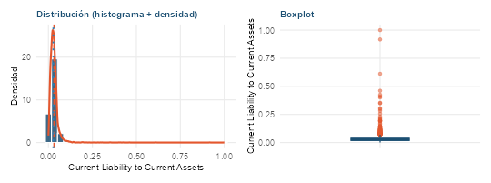

El histograma de **Current Liability to Current Assets** muestra un marcado sesgo a la derecha (asimetría positiva), con una media de **0.0316** y una mediana de **0.0277**. La curtosis observada de **346.37** indica la concentración de observaciones alrededor de la zona central, con posibles valores atípicos en las colas. Esta morfología sugiere una alta homogeneidad en el grueso de las empresas analizadas, con comportamientos extremos puntuales a monitorear en el preprocesamiento.

#### Net Income to Total Assets

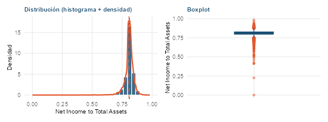

El histograma de **Net Income to Total Assets** muestra un marcado sesgo a la izquierda (asimetría negativa), con una media de **0.8077** y una mediana de **0.8107**. La curtosis observada de **49.73** indica la concentración de observaciones alrededor de la zona central, con posibles valores atípicos en las colas. Esta morfología sugiere una alta homogeneidad en el grueso de las empresas analizadas, con comportamientos extremos puntuales a monitorear en el preprocesamiento.

#### Total assets to GNP price

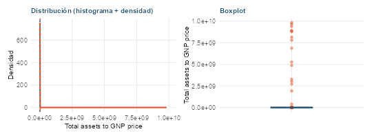

El histograma de **Total assets to GNP price** muestra un marcado sesgo a la derecha (asimetría positiva), con una media de **18266862.1788** y una mediana de **0.0021**. La curtosis observada de **512.27** indica la concentración de observaciones alrededor de la zona central, con posibles valores atípicos en las colas. Esta morfología sugiere una alta homogeneidad en el grueso de las empresas analizadas, con comportamientos extremos puntuales a monitorear en el preprocesamiento.

#### No-credit Interval

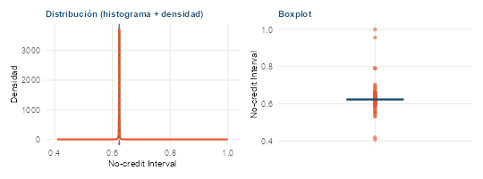

El histograma de **No-credit Interval** muestra un marcado sesgo a la derecha (asimetría positiva), con una media de **0.6239** y una mediana de **0.6239**. La curtosis observada de **814.05** indica la concentración de observaciones alrededor de la zona central, con posibles valores atípicos en las colas. Esta morfología sugiere una alta homogeneidad en el grueso de las empresas analizadas, con comportamientos extremos puntuales a monitorear en el preprocesamiento.

#### Gross Profit to Sales

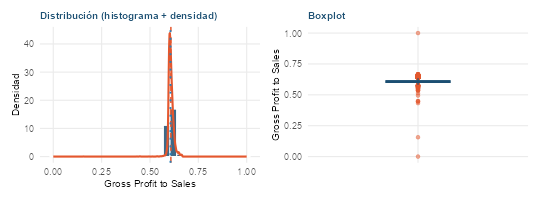

El histograma de **Gross Profit to Sales** muestra un marcado sesgo a la izquierda (asimetría negativa), con una media de **0.6080** y una mediana de **0.6061**. La curtosis observada de **377.59** indica la concentración de observaciones alrededor de la zona central, con posibles valores atípicos en las colas. Esta morfología sugiere una alta homogeneidad en el grueso de las empresas analizadas, con comportamientos extremos puntuales a monitorear en el preprocesamiento.

#### Net Income to Stockholder’s Equity

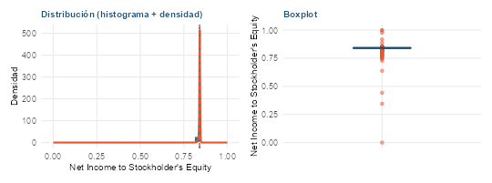

El histograma de **Net Income to Stockholder’s Equity** muestra un marcado sesgo a la izquierda (asimetría negativa), con una media de **0.8404** y una mediana de **0.8412**. La curtosis observada de **1737.30** indica la concentración de observaciones alrededor de la zona central, con posibles valores atípicos en las colas. Esta morfología sugiere una alta homogeneidad en el grueso de las empresas analizadas, con comportamientos extremos puntuales a monitorear en el preprocesamiento.

#### Liability to Equity

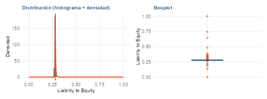

El histograma de **Liability to Equity** muestra un marcado sesgo a la derecha (asimetría positiva), con una media de **0.2804** y una mediana de **0.2788**. La curtosis observada de **1257.71** indica la concentración de observaciones alrededor de la zona central, con posibles valores atípicos en las colas. Esta morfología sugiere una alta homogeneidad en el grueso de las empresas analizadas, con comportamientos extremos puntuales a monitorear en el preprocesamiento.

#### Degree of Financial Leverage (DFL)

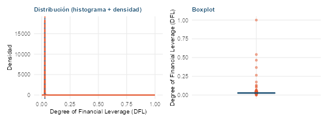

El histograma de **Degree of Financial Leverage (DFL)** muestra un marcado sesgo a la derecha (asimetría positiva), con una media de **0.0276** y una mediana de **0.0268**. La curtosis observada de **2051.67** indica la concentración de observaciones alrededor de la zona central, con posibles valores atípicos en las colas. Esta morfología sugiere una alta homogeneidad en el grueso de las empresas analizadas, con comportamientos extremos puntuales a monitorear en el preprocesamiento.

#### Interest Coverage Ratio (Interest expense to EBIT)

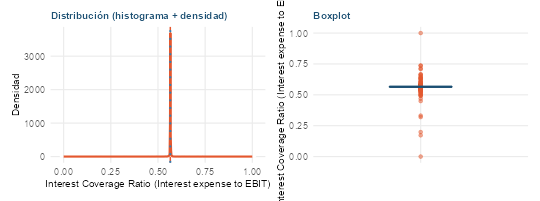

El histograma de **Interest Coverage Ratio (Interest expense to EBIT)** muestra un marcado sesgo a la izquierda (asimetría negativa), con una media de **0.5653** y una mediana de **0.5653**. La curtosis observada de **750.18** indica la concentración de observaciones alrededor de la zona central, con posibles valores atípicos en las colas. Esta morfología sugiere una alta homogeneidad en el grueso de las empresas analizadas, con comportamientos extremos puntuales a monitorear en el preprocesamiento.

#### Equity to Liability

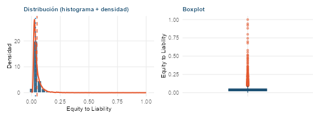

El histograma de **Equity to Liability** muestra un marcado sesgo a la derecha (asimetría positiva), con una media de **0.0476** y una mediana de **0.0339**. La curtosis observada de **98.72** indica la concentración de observaciones alrededor de la zona central, con posibles valores atípicos en las colas. Esta morfología sugiere una alta homogeneidad en el grueso de las empresas analizadas, con comportamientos extremos puntuales a monitorear en el preprocesamiento.

En general, las 93 variables muestran distribuciones muy diversas: varias se concentran en un rango angosto con colas largas (sesgo marcado y curtosis alta), mientras que otras se acercan más a una forma simétrica. Estos casos deben revisarse en etapas posteriores antes de decidir si requieren algún tratamiento (transformación, winsorizing, o dejarlos igual).

### 0.4.4 Distribución de la variable objetivo

```r
conteo     <- table(train_df[[TARGET]])
porcentaje <- prop.table(conteo) * 100

cat("Total de empresas en train:", nrow(train_df), "\n")
```

```
## Total de empresas en train: 5456
```

```r
cat(sprintf("No quebradas (0): %5d (%.2f%%)\n", conteo["0"], porcentaje["0"]))
```

```
## No quebradas (0):  5269 (96.57%)
```

```r
cat(sprintf("Quebradas   (1): %5d (%.2f%%)\n", conteo["1"], porcentaje["1"]))
```

```
## Quebradas   (1):   187 (3.43%)
```

```r
cat(sprintf("Ratio de desbalance: %.1f : 1\n", conteo["0"] / conteo["1"]))
```

```
## Ratio de desbalance: 28.2 : 1
```

```r
df_plot <- tibble(clase = names(conteo), n = as.numeric(conteo)) %>%
  mutate(label = TARGET_LABELS[clase], pct = n / sum(n) * 100)

p_barras <- ggplot(df_plot, aes(x = label, y = n, fill = clase)) +
  geom_col(width = 0.6) +
  geom_text(aes(label = sprintf("%s\n(%.2f%%)", comma(n), pct)),
            vjust = -0.3, fontface = "bold", size = 3.5) +
  scale_fill_manual(values = TARGET_COLORS) +
  labs(title = "Conteo de empresas por clase (train)", x = NULL,
       y = "Número de empresas") +
  ylim(0, max(df_plot$n) * 1.2) +
  tema_eda

p_dona <- ggplot(df_plot, aes(x = 2, y = pct, fill = clase)) +
  geom_col(color = "white", linewidth = 1.2) +
  coord_polar(theta = "y") +
  xlim(0.5, 2.5) +
  scale_fill_manual(values = TARGET_COLORS, labels = TARGET_LABELS,
                     name = NULL) +
  geom_text(aes(label = sprintf("%.2f%%", pct)),
            position = position_stack(vjust = 0.5), color = "white",
            fontface = "bold") +
  labs(title = "Proporción de empresas por clase (train)") +
  theme_void() +
  theme(plot.title = element_text(face = "bold", size = 13, color = COLOR_MAIN,
                                   hjust = 0.5),
        legend.position = "right")

p_barras + p_dona
```

[figure not shown]

## 0.5 Análisis de outliers y sesgo (sobre `train`)

Antes de pasar al análisis bivariado, es importante identificar qué variables tienen distribuciones muy sesgadas y/o outliers extremos, ya que esto afecta tanto la interpretación visual como la elección de modelos y transformaciones en la fase de Machine Learning.

### 0.5.1 Top 10 variables con mayor sesgo, en valor absoluto (train)

```r
# type = 2 replica la fórmula de sesgo "clásica" (similar a pandas .skew())
skew_vals <- sapply(train_df[num_vars], function(x) e1071::skewness(x, na.rm = TRUE, type = 2))
skew_orden <- names(sort(abs(skew_vals), decreasing = TRUE))

top10_skew <- skew_vals[skew_orden[1:10]]
print(round(top10_skew, 2))
```

```
##                           Current Ratio                  Fixed Assets to Assets                   Net Value Growth Rate
##                                   73.86                                   73.86                                   71.82
##        Contingent liabilities/Net worth Realized Sales Gross Profit Growth Rate                   Operating Profit Rate
##                                   71.47                                   69.87                                  -69.78
##            Operating Profit Growth Rate                      Cash Flow to Sales          Working capitcal Turnover Rate
##                                  -67.59                                  -65.51                                  -64.67
##             After-tax net Interest Rate
##                                  -61.97
```

```r
top_skew_vars <- skew_orden[1:6]
```

Las variables presentan valores de sesgo muy altos, tanto positivos como negativos. Esto indica que varias distribuciones están alejadas de una distribución simétrica y pueden presentar valores extremos.

**Conclusión:** Varias variables presentan un sesgo elevado, lo que sugiere la presencia de distribuciones muy asimétricas y posibles valores extremos. Estas variables deberán revisarse durante el preprocesamiento para determinar si requieren alguna transformación, especialmente si se utilizan modelos sensibles a la escala o a la distribución de los datos.

### 0.5.2 Boxplots de las variables más sesgadas

```r
plot_box_skew <- function(var) {
  ggplot(train_df, aes(x = "", y = .data[[var]])) +
    geom_boxplot(fill = COLOR_MAIN, color = COLOR_MAIN, width = 0.35,
                 outlier.color = COLOR_RISK, outlier.alpha = 0.5, outlier.size = 1.5) +
    labs(title = sprintf("%s\n(skew = %.1f)", str_wrap(var, 28), skew_vals[var]),
         x = NULL, y = NULL) +
    tema_eda
}

wrap_plots(lapply(top_skew_vars, plot_box_skew), ncol = 3) +
  plot_annotation(title = "Variables con mayor sesgo (train)",
                   theme = theme(plot.title = element_text(face = "bold", size = 15)))
```

[figure not shown]

**Conclusión:** Los boxplots muestran que las variables con mayor sesgo presentan valores atípicos muy alejados de la mayoría de las observaciones. En varias de ellas, estos valores extremos explican gran parte del sesgo observado. Por ahora no se deberían eliminar automáticamente, ya que primero es necesario determinar si representan errores o situaciones reales de las empresas.

### 0.5.3 Top 15 variables con más outliers (regla IQR)

```r
pct_outliers_iqr <- function(x) {
  q   <- quantile(x, c(0.25, 0.75), na.rm = TRUE)
  iqr <- q[2] - q[1]
  lower <- q[1] - 1.5 * iqr
  upper <- q[2] + 1.5 * iqr
  mean(x < lower | x > upper, na.rm = TRUE) * 100
}

outlier_pct <- sort(sapply(train_df[num_vars], pct_outliers_iqr), decreasing = TRUE)
top15_out   <- outlier_pct[1:15]
print(round(top15_out, 1))
```

```
##                 Degree of Financial Leverage (DFL)                    Fixed Assets Turnover Frequency
##                                               22.2                                               20.8
## Interest Coverage Ratio (Interest expense to EBIT)                        Current Asset Turnover Rate
##                                               20.7                                               20.6
##                            Total Asset Growth Rate                             Interest Expense Ratio
##                                               20.1                                               19.2
##                             Cash Flow to Liability                                 No-credit Interval
##                                               18.1                                               16.4
##        Non-industry income and expenditure/revenue                                 Cash Flow to Sales
##                                               16.1                                               15.5
##                       Operating Profit Growth Rate                  Continuous Net Profit Growth Rate
##                                               15.3                                               15.3
##                   After-tax Net Profit Growth Rate                     Regular Net Profit Growth Rate
##                                               15.2                                               15.2
##                          Inventory/Working Capital
##                                               13.9
```

```r
df_out <- tibble(variable = names(top15_out), pct = as.numeric(top15_out))

ggplot(df_out, aes(x = reorder(variable, pct), y = pct)) +
  geom_col(fill = COLOR_MAIN) +
  geom_text(aes(label = sprintf("%.1f%%", pct)), hjust = -0.15, size = 3.2,
            color = COLOR_MAIN, fontface = "bold") +
  coord_flip(clip = "off") +
  labs(title = "Top 15 variables con más outliers (IQR, train)",
       x = NULL, y = "% de empresas marcadas como outlier") +
  expand_limits(y = max(df_out$pct) * 1.15) +
  tema_eda
```

[figure not shown]

Las variables con mayor proporción de valores atípicos suelen ser **Degree of Financial Leverage (DFL)**, **Fixed Assets Turnover Frequency** e **Interest Coverage Ratio**, con alrededor del 20 % de empresas marcadas como outliers. También destacan **Current Asset Turnover Rate**, **Total Asset Growth Rate** e **Interest Expense Ratio**, con porcentajes similares. Las demás variables del top 15 presentan entre aproximadamente 14 % y 18 % de observaciones marcadas como outliers.

En general, varias variables presentan una proporción considerable de valores atípicos. Sin embargo, esto no significa que deban eliminarse automáticamente, ya que pueden representar situaciones financieras reales de algunas empresas. Estos resultados deberán considerarse posteriormente al definir el preprocesamiento de los datos.

## 0.6 Análisis bivariado: variables vs. objetivo (sobre `train`)

### 0.6.1 Variables más importantes según Random Forest

Usamos un Random Forest **entrenado únicamente con `train`** para tener una primera idea de qué variables separan mejor a las empresas que quiebran de las que no. Esto es solo exploratorio: nos ayuda a elegir qué variables mirar con más detalle en los gráficos siguientes, no es el modelo final del proyecto.

> **¿Por qué Random Forest?** Se eligió porque no necesita que las variables estén en la misma escala ni sigan una relación lineal con la quiebra, es robusto ante los outliers que ya se identificaron en los datos y entrega una medida de importancia de variables por defecto, facilitando la interpretación para fines exploratorios.

```r
# Nota metodológica: la imputación con la mediana que se hace aquí es temporal y
# solo existe para poder entrenar el Random Forest exploratorio; no se aplica a
# train_df ni al dataset real. La imputación definitiva se decide en la etapa de
# preprocesamiento, después del EDA.

X_rf <- train_df %>% select(-all_of(TARGET), -`Net Income Flag`)

X_rf <- X_rf %>%
  mutate(across(everything(), ~ ifelse(is.infinite(.x), NA, .x))) %>%
  mutate(across(everything(), ~ ifelse(is.na(.x), median(.x, na.rm = TRUE), .x)))

y_train_factor <- factor(train_df[[TARGET]], levels = c(0, 1),
                          labels = c("No", "Si"))

set.seed(RANDOM_STATE)
rf <- randomForest(x = X_rf, y = y_train_factor, ntree = 100, importance = TRUE)

# MeanDecreaseGini es el equivalente conceptual a feature_importances_ de sklearn
importancias <- importance(rf, type = 2)[, 1]
importancias <- sort(importancias, decreasing = TRUE)

cat("============================================================\n")
cat("TOP 15 VARIABLES MÁS IMPORTANTES (Random Forest, train)\n")
```

```
## TOP 15 VARIABLES MÁS IMPORTANTES (Random Forest, train)
```

```r
cat("============================================================\n")
print(round(head(importancias, 15), 3))
```

```
##                              Net Value Growth Rate            Persistent EPS in the Last Four Seasons
##                                             13.636                                             10.215
##                 Net Income to Stockholder's Equity                               Borrowing dependency
##                                             10.044                                              9.609
##              Net profit before tax/Paid-in capital                             Working Capital/Equity
##                                              8.345                                              7.247
##                 Degree of Financial Leverage (DFL)                Interest-bearing debt interest rate
##                                              7.012                                              7.011
##                         Total debt/Total net worth                            Net Value Per Share (B)
##                                              6.903                                              6.826
##           Per Share Net profit before tax (Yuan ¥)        Non-industry income and expenditure/revenue
##                                              6.398                                              6.305
##                                Equity to Liability                    Working Capital to Total Assets
##                                              5.830                                              5.650
## Interest Coverage Ratio (Interest expense to EBIT)
##                                              5.610
```

```r
top_15_features <- names(head(importancias, 15))
top_6_features  <- names(head(importancias, 6))

df_imp <- tibble(variable = names(head(importancias, 15)),
                  importancia = as.numeric(head(importancias, 15))) %>%
  mutate(top6 = variable %in% top_6_features)

ggplot(df_imp, aes(x = reorder(variable, importancia), y = importancia, fill = top6)) +
  geom_col() +
  geom_text(aes(label = sprintf("%.3f", importancia)), hjust = -0.15, size = 3,
            fontface = "bold", color = COLOR_MAIN) +
  coord_flip(clip = "off") +
  scale_fill_manual(values = c(`TRUE` = COLOR_RISK, `FALSE` = COLOR_MAIN),
                     labels = c(`TRUE` = "Top 6 (usadas más abajo)",
                                `FALSE` = "Resto del top 15"),
                     name = NULL) +
  labs(title = "Top 15 variables más importantes\n(Random Forest sobre train)",
       x = NULL, y = "Importancia (MeanDecreaseGini)") +
  expand_limits(y = max(df_imp$importancia) * 1.2) +
  tema_eda +
  theme(legend.position = "bottom")
```

[figure not shown]

> **¿Qué hizo Random Forest aquí?** Es un modelo que, al entrenarse, mide qué tanto le “ayudó” cada variable para diferenciar empresas que quiebran de las que no. Cuanto mayor el número de importancia, más útil fue esa variable para el modelo. Entre las más importantes suelen aparecer variables de rentabilidad para el accionista (`Net Income to Stockholder's Equity`), márgenes operativos y ratios de endeudamiento — lo cual tiene sentido: una empresa que no genera ganancias para sus dueños y está muy endeudada es, intuitivamente, más propensa a quebrar.

Random Forest se utiliza aquí como una **herramienta exploratoria**, no como un ranking definitivo de importancia. Dos sesgos conocidos a tener en cuenta:

- **Favorece variables continuas sobre categóricas:** una variable binaria como `Liability-Assets Flag` casi nunca aparecerá entre las “más importantes”, aunque sí sea relevante.
- **Reparte la importancia entre variables correlacionadas:** cuando varias variables miden algo muy parecido (como las distintas versiones de ROA), el modelo divide el “crédito” entre ellas, lo que puede subestimar su relevancia individual.

### 0.6.2 Variables más importantes vs. objetivo

```r
plot_box_target <- function(var) {
  q1  <- quantile(train_df[[var]], 0.01, na.rm = TRUE)
  q99 <- quantile(train_df[[var]], 0.99, na.rm = TRUE)
  df_f <- train_df %>% filter(.data[[var]] >= q1, .data[[var]] <= q99)

  ggplot(df_f, aes(x = as.factor(.data[[TARGET]]), y = .data[[var]],
                    fill = as.factor(.data[[TARGET]]))) +
    geom_boxplot(width = 0.45, outlier.alpha = 0.35, outlier.size = 1.2) +
    scale_x_discrete(labels = TARGET_LABELS) +
    scale_fill_manual(values = TARGET_COLORS) +
    labs(title = str_wrap(var, 32), x = NULL, y = var) +
    tema_eda
}

wrap_plots(lapply(top_6_features, plot_box_target), ncol = 3) +
  plot_annotation(
    title = "Variables más importantes vs. objetivo\n(train, sin el 1% de valores más extremos)",
    theme = theme(plot.title = element_text(face = "bold", size = 15))
  )
```

[figure not shown]

En conjunto, el patrón refuerza lo que se venía viendo en la sección: **rentabilidad baja y endeudamiento alto son las señales más visibles de riesgo**, mientras que otras variables importantes para el modelo probablemente aportan valor más por su interacción con las demás que por separarse solas en un boxplot.

### 0.6.3 Comparación bivariada de las 93 variables numéricas

Antes de entrar en pruebas formales, se resumen las 93 variables numéricas en una sola tabla (en vez de mirarlas una por una), ordenada por la fuerza de su relación con el objetivo. Aquí ya se usa **correlación de Spearman** en vez de Pearson; la justificación completa está en la sección de correlaciones más adelante, pero en resumen: con 93 variables no es viable verificar normalidad una por una, y ya se documentó sesgo y outliers fuertes que distorsionan a Pearson.

```r
corr_spearman_objetivo <- sapply(train_df[num_vars], function(x) {
  cor(x, train_df[[TARGET]], method = "spearman", use = "pairwise.complete.obs")
})

tabla_bivariada <- tibble(
  Variable = num_vars,
  `Correlación Spearman (r)` = corr_spearman_objetivo[num_vars],
  `Media (No quiebra)` = sapply(num_vars, function(v)
    mean(train_df[[v]][train_df[[TARGET]] == 0], na.rm = TRUE)),
  `Media (Quiebra)` = sapply(num_vars, function(v)
    mean(train_df[[v]][train_df[[TARGET]] == 1], na.rm = TRUE)),
  `Mediana (No quiebra)` = sapply(num_vars, function(v)
    median(train_df[[v]][train_df[[TARGET]] == 0], na.rm = TRUE)),
  `Mediana (Quiebra)` = sapply(num_vars, function(v)
    median(train_df[[v]][train_df[[TARGET]] == 1], na.rm = TRUE))
) %>%
  arrange(desc(abs(`Correlación Spearman (r)`)))

tabla_bivariada %>%
  kable(digits = 4,
        caption = "Comparación bivariada de las 93 variables numéricas vs. Bankrupt? (ordenadas por relevancia)") %>%
  kable_styling(bootstrap_options = c("striped", "hover", "condensed"),
                full_width = FALSE, font_size = 12) %>%
  scroll_box(height = "420px")
```

Table 3: Table 4: Comparación bivariada de las 93 variables numéricas vs. Bankrupt? (ordenadas por relevancia)

| Variable | Correlación Spearman (r) | Media (No quiebra) | Media (Quiebra) | Mediana (No quiebra) | Mediana (Quiebra) |
| --- | --- | --- | --- | --- | --- |
| Persistent EPS in the Last Four Seasons | -0.2437 | 2.301000e-01 | 1.893000e-01 | 2.253e-01 | 1.969e-01 |
| Net Income to Total Assets | -0.2403 | 8.101000e-01 | 7.402000e-01 | 8.116e-01 | 7.645e-01 |
| Net profit before tax/Paid-in capital | -0.2382 | 1.837000e-01 | 1.479000e-01 | 1.791e-01 | 1.551e-01 |
| Per Share Net profit before tax (Yuan ¥) | -0.2375 | 1.855000e-01 | 1.481000e-01 | 1.804e-01 | 1.555e-01 |
| Retained Earnings to Total Assets | -0.2356 | 9.356000e-01 | 9.056000e-01 | 9.381e-01 | 9.123e-01 |
| Continuous interest rate (after tax) | -0.2338 | 7.815000e-01 | 7.808000e-01 | 7.816e-01 | 7.813e-01 |
| Total debt/Total net worth | 0.2305 | 5.056937e+06 | 1.855615e+07 | 5.400e-03 | 1.570e-02 |
| Total income/Total expense | -0.2300 | 2.400000e-03 | 2.100000e-03 | 2.300e-03 | 2.000e-03 |
| ROA(B) before interest and depreciation after tax | -0.2296 | 5.569000e-01 | 4.631000e-01 | 5.544e-01 | 4.885e-01 |
| ROA(C) before interest and depreciation before interest | -0.2281 | 5.083000e-01 | 4.191000e-01 | 5.049e-01 | 4.431e-01 |
| Debt ratio % | 0.2280 | 1.108000e-01 | 1.889000e-01 | 1.092e-01 | 1.874e-01 |
| Net worth/Assets | -0.2280 | 8.892000e-01 | 8.111000e-01 | 8.908e-01 | 8.126e-01 |
| Equity to Liability | -0.2280 | 4.850000e-02 | 2.440000e-02 | 3.450e-02 | 1.870e-02 |
| ROA(A) before interest and % after tax | -0.2279 | 5.621000e-01 | 4.586000e-01 | 5.618e-01 | 4.901e-01 |
| Borrowing dependency | 0.2277 | 3.740000e-01 | 3.923000e-01 | 3.725e-01 | 3.827e-01 |
| After-tax net Interest Rate | -0.2257 | 8.092000e-01 | 8.084000e-01 | 8.094e-01 | 8.091e-01 |
| Net Income to Stockholder’s Equity | -0.2245 | 8.409000e-01 | 8.245000e-01 | 8.412e-01 | 8.367e-01 |
| Pre-tax net Interest Rate | -0.2237 | 7.973000e-01 | 7.965000e-01 | 7.975e-01 | 7.971e-01 |
| Net Value Per Share (B) | -0.2153 | 1.913000e-01 | 1.601000e-01 | 1.849e-01 | 1.579e-01 |
| Net Value Per Share (A) | -0.2151 | 1.913000e-01 | 1.600000e-01 | 1.850e-01 | 1.579e-01 |
| Net Value Per Share (C) | -0.2135 | 1.913000e-01 | 1.602000e-01 | 1.850e-01 | 1.579e-01 |
| Quick Ratio | -0.2124 | 8.094515e+06 | 4.935829e+07 | 7.600e-03 | 2.700e-03 |
| Liability to Equity | 0.2114 | 2.799000e-01 | 2.953000e-01 | 2.787e-01 | 2.858e-01 |
| Non-industry income and expenditure/revenue | -0.2085 | 3.035000e-01 | 3.025000e-01 | 3.035e-01 | 3.033e-01 |
| Net Value Growth Rate | -0.2083 | 2.562156e+05 | 4.989305e+07 | 5.000e-04 | 4.000e-04 |
| Current Ratio | -0.2008 | 5.219207e+05 | 6.800000e-03 | 1.070e-02 | 5.900e-03 |
| Current Liability to Current Assets | 0.2007 | 3.040000e-02 | 6.340000e-02 | 2.720e-02 | 4.880e-02 |
| Operating Profit Per Share (Yuan ¥) | -0.1993 | 1.097000e-01 | 8.700000e-02 | 1.048e-01 | 9.030e-02 |
| Operating profit/Paid-in capital | -0.1991 | 1.096000e-01 | 8.710000e-02 | 1.046e-01 | 9.040e-02 |
| Quick Assets/Current Liability | -0.1990 | 4.649839e+06 | 4.700000e-03 | 8.100e-03 | 3.400e-03 |

[output cut: 63 more lines]

La tabla confirma, a nivel general, lo que ya se venía observando: las variables mejor posicionadas (mayor `|r|`) combinan medias/medianas claramente distintas entre empresas sanas y quebradas, mientras que las últimas filas tienen valores casi idénticos entre ambos grupos — es decir, aportan poco de forma univariada.

### 0.6.4 Inferencia estadística: variables numéricas vs. objetivo

El análisis descriptivo y los boxplots anteriores sugieren diferencias entre empresas solventes y quebradas, pero no permiten determinar si esas diferencias son compatibles con la variabilidad muestral. La inferencia estadística contrasta, para cada ratio:

- **H₀:** la distribución del ratio es igual en empresas que no quiebran y en empresas que sí quiebran.
- **H₁:** la distribución del ratio difiere entre ambos estados de quiebra.

Se usa $\alpha = 0.05$. Como el objetivo es binario e independiente de cada ratio numérico, se comparan dos grupos independientes (0 = no quiebra; 1 = quiebra).

**Selección de la prueba:** se evalúa normalidad razonable en ambos grupos con Shapiro-Wilk (máximo 5.000 observaciones por grupo, muestreadas con semilla fija), sesgo y porcentaje de outliers (IQR); Levene se reporta solo como diagnóstico adicional. En estos datos, las 93 variables incumplen la normalidad razonable, así que se usa **Mann-Whitney U bilateral** para todas. Como tamaño de efecto se reporta la **correlación biserial de rangos** ($r_{rb}$, entre -1 y 1): positivo indica que el ratio tiende a ser mayor en empresas sin quiebra; negativo, mayor en empresas quebradas. Guía descriptiva de magnitud: $|r_{rb}|\approx 0.10$ pequeño, $0.30$ moderado, $0.50$ grande.

```r
# Requiere el paquete car para Levene (install.packages("car") si hace falta)
ALPHA <- 0.05

inferencia_una_var <- function(var) {
  grupo_0 <- train_df[[var]][train_df[[TARGET]] == 0]
  grupo_1 <- train_df[[var]][train_df[[TARGET]] == 1]
  grupo_0 <- grupo_0[!is.na(grupo_0)]
  grupo_1 <- grupo_1[!is.na(grupo_1)]

  set.seed(RANDOM_STATE)
  muestra_0 <- if (length(grupo_0) > 5000) sample(grupo_0, 5000) else grupo_0
  p_shapiro_0 <- shapiro.test(muestra_0)$p.value
  p_shapiro_1 <- shapiro.test(grupo_1)$p.value

  grupo_f  <- factor(c(rep("0", length(grupo_0)), rep("1", length(grupo_1))))
  p_levene <- car::leveneTest(c(grupo_0, grupo_1) ~ grupo_f, center = median)$`Pr(>F)`[1]

  sesgo_0    <- e1071::skewness(grupo_0, type = 2)
  sesgo_1    <- e1071::skewness(grupo_1, type = 2)
  pct_out_0  <- pct_outliers_iqr(grupo_0)
  pct_out_1  <- pct_outliers_iqr(grupo_1)

  normalidad_razonable <- p_shapiro_0 >= ALPHA && p_shapiro_1 >= ALPHA &&
    abs(sesgo_0) <= 1 && abs(sesgo_1) <= 1 && max(pct_out_0, pct_out_1) <= 5

  prueba <- wilcox.test(grupo_0, grupo_1, alternative = "two.sided", exact = FALSE)
  U  <- as.numeric(prueba$statistic)
  n0 <- length(grupo_0); n1 <- length(grupo_1)

  tibble(
    Variable = var, `N (0)` = n0, `N (1)` = n1,
    `Mediana (0)` = median(grupo_0), `Mediana (1)` = median(grupo_1),
    `p Shapiro (0)` = p_shapiro_0, `p Shapiro (1)` = p_shapiro_1, `p Levene` = p_levene,
    `Normalidad razonable` = normalidad_razonable,
    U = U, `p-value` = prueba$p.value,
    `r biserial` = 2 * U / (n0 * n1) - 1
  )
}

resultados_inferencia_num <- map_dfr(num_vars, inferencia_una_var)

# Holm controla el error familiar entre las 93 pruebas y es menos conservador
# que Bonferroni; p.adjust(method = "holm") ya implementa Holm-Bonferroni.
resultados_inferencia_num <- resultados_inferencia_num %>%
  mutate(`p ajustado (Holm)` = p.adjust(`p-value`, method = "holm"),
         Decisión = ifelse(`p ajustado (Holm)` < ALPHA, "Se rechaza H0", "No se rechaza H0")) %>%
  arrange(`p ajustado (Holm)`)

resultados_inferencia_num %>%
  select(Variable, `N (0)`, `N (1)`, `Mediana (0)`, `Mediana (1)`,
         U, `p-value`, `p ajustado (Holm)`, `r biserial`, Decisión) %>%
  kable(digits = c(0, 0, 0, 4, 4, 1, 3, 3, 3, 0)) %>%
  kable_styling(bootstrap_options = c("striped", "hover", "condensed"),
                full_width = FALSE, font_size = 12) %>%
  scroll_box(height = "420px")
```

| Variable | N (0) | N (1) | Mediana (0) | Mediana (1) | U | p-value | p ajustado (Holm) | r biserial | Decisión |
| --- | --- | --- | --- | --- | --- | --- | --- | --- | --- |
| ROA(C) before interest and depreciation before interest | 5269 | 187 | 5.049e-01 | 4.431e-01 | 849233.5 | 0.000 | 0.000 | 0.724 | Se rechaza H0 |
| ROA(A) before interest and % after tax | 5269 | 187 | 5.618e-01 | 4.901e-01 | 848899.0 | 0.000 | 0.000 | 0.723 | Se rechaza H0 |
| ROA(B) before interest and depreciation after tax | 5269 | 187 | 5.544e-01 | 4.885e-01 | 851613.5 | 0.000 | 0.000 | 0.729 | Se rechaza H0 |
| Operating Gross Margin | 5269 | 187 | 6.063e-01 | 5.986e-01 | 733281.5 | 0.000 | 0.000 | 0.488 | Se rechaza H0 |
| Realized Sales Gross Margin | 5269 | 187 | 6.063e-01 | 5.988e-01 | 731230.0 | 0.000 | 0.000 | 0.484 | Se rechaza H0 |
| Operating Profit Rate | 5269 | 187 | 9.990e-01 | 9.989e-01 | 787093.5 | 0.000 | 0.000 | 0.598 | Se rechaza H0 |
| Pre-tax net Interest Rate | 5269 | 187 | 7.975e-01 | 7.971e-01 | 842347.5 | 0.000 | 0.000 | 0.710 | Se rechaza H0 |
| After-tax net Interest Rate | 5269 | 187 | 8.094e-01 | 8.091e-01 | 845457.5 | 0.000 | 0.000 | 0.716 | Se rechaza H0 |
| Non-industry income and expenditure/revenue | 5269 | 187 | 3.035e-01 | 3.033e-01 | 818570.5 | 0.000 | 0.000 | 0.662 | Se rechaza H0 |
| Continuous interest rate (after tax) | 5269 | 187 | 7.816e-01 | 7.813e-01 | 858210.0 | 0.000 | 0.000 | 0.742 | Se rechaza H0 |
| Cash flow rate | 5269 | 187 | 4.653e-01 | 4.613e-01 | 727607.0 | 0.000 | 0.000 | 0.477 | Se rechaza H0 |
| Tax rate (A) | 5269 | 187 | 8.320e-02 | 0.000e+00 | 734302.0 | 0.000 | 0.000 | 0.491 | Se rechaza H0 |
| Net Value Per Share (B) | 5269 | 187 | 1.849e-01 | 1.579e-01 | 829304.0 | 0.000 | 0.000 | 0.683 | Se rechaza H0 |
| Net Value Per Share (A) | 5269 | 187 | 1.850e-01 | 1.579e-01 | 828915.5 | 0.000 | 0.000 | 0.683 | Se rechaza H0 |
| Net Value Per Share (C) | 5269 | 187 | 1.850e-01 | 1.579e-01 | 826500.0 | 0.000 | 0.000 | 0.678 | Se rechaza H0 |
| Persistent EPS in the Last Four Seasons | 5269 | 187 | 2.253e-01 | 1.969e-01 | 873690.0 | 0.000 | 0.000 | 0.773 | Se rechaza H0 |
| Cash Flow Per Share | 5269 | 187 | 3.227e-01 | 3.172e-01 | 701695.5 | 0.000 | 0.000 | 0.424 | Se rechaza H0 |
| Operating Profit Per Share (Yuan ¥) | 5269 | 187 | 1.048e-01 | 9.030e-02 | 804304.0 | 0.000 | 0.000 | 0.633 | Se rechaza H0 |
| Per Share Net profit before tax (Yuan ¥) | 5269 | 187 | 1.804e-01 | 1.555e-01 | 863984.5 | 0.000 | 0.000 | 0.754 | Se rechaza H0 |
| After-tax Net Profit Growth Rate | 5269 | 187 | 6.894e-01 | 6.892e-01 | 686456.0 | 0.000 | 0.000 | 0.393 | Se rechaza H0 |
| Regular Net Profit Growth Rate | 5269 | 187 | 6.894e-01 | 6.892e-01 | 682848.5 | 0.000 | 0.000 | 0.386 | Se rechaza H0 |
| Continuous Net Profit Growth Rate | 5269 | 187 | 2.176e-01 | 2.176e-01 | 683955.5 | 0.000 | 0.000 | 0.388 | Se rechaza H0 |
| Net Value Growth Rate | 5269 | 187 | 5.000e-04 | 4.000e-04 | 818271.5 | 0.000 | 0.000 | 0.661 | Se rechaza H0 |
| Current Ratio | 5269 | 187 | 1.070e-02 | 5.900e-03 | 806608.0 | 0.000 | 0.000 | 0.637 | Se rechaza H0 |
| Quick Ratio | 5269 | 187 | 7.600e-03 | 2.700e-03 | 824757.0 | 0.000 | 0.000 | 0.674 | Se rechaza H0 |
| Interest Expense Ratio | 5269 | 187 | 6.307e-01 | 6.303e-01 | 696667.5 | 0.000 | 0.000 | 0.414 | Se rechaza H0 |
| Net worth/Assets | 5269 | 187 | 8.908e-01 | 8.126e-01 | 849107.0 | 0.000 | 0.000 | 0.724 | Se rechaza H0 |
| Long-term fund suitability ratio (A) | 5269 | 187 | 5.700e-03 | 5.200e-03 | 690555.0 | 0.000 | 0.000 | 0.402 | Se rechaza H0 |
| Operating profit/Paid-in capital | 5269 | 187 | 1.046e-01 | 9.040e-02 | 803935.0 | 0.000 | 0.000 | 0.632 | Se rechaza H0 |
| Net profit before tax/Paid-in capital | 5269 | 187 | 1.791e-01 | 1.551e-01 | 864992.0 | 0.000 | 0.000 | 0.756 | Se rechaza H0 |

[output cut: 63 more lines]

```r
n_rechaza <- sum(resultados_inferencia_num$Decisión == "Se rechaza H0")
cat(sprintf("Variables evaluadas: %d\n", nrow(resultados_inferencia_num)))
```

```
## Variables evaluadas: 93
```

```r
cat(sprintf("Con evidencia después de Holm: %d\n", n_rechaza))
```

```
## Con evidencia después de Holm: 84
```

```r
cat(sprintf("Sin evidencia suficiente después de Holm: %d\n",
            nrow(resultados_inferencia_num) - n_rechaza))
```

```
## Sin evidencia suficiente después de Holm: 9
```

Realizar 93 contrastes con $\alpha=0.05$ sin ajuste aumentaría la probabilidad de falsos positivos: aun si todas las H₀ fueran ciertas, se esperarían en promedio $93 \times 0.05 \approx 4{,}65$ rechazos solo por azar. Después de la corrección de Holm, la mayoría de las variables numéricas conserva evidencia de diferencia entre empresas sanas y quebradas, y solo un grupo pequeño no la conserva — esta significancia abundante es compatible con el tamaño muestral y **no implica que todas las variables tengan utilidad práctica o predictiva**; la magnitud del efecto ($r_{rb}$) y el contexto financiero siguen siendo necesarios para juzgar relevancia. Este resultado describe asociación, no causalidad.

### 0.6.5 `Liability-Assets Flag` vs. objetivo

Análisis bivariado de la única variable categórica con la variable objetivo.

**`Liability-Assets Flag`:** es la única variable categórica del dataset. Es binaria e indica si los pasivos de la empresa superan a sus activos (`1`) o no (`0`).

```r
tabla_pct    <- prop.table(table(train_df$`Liability-Assets Flag`, train_df[[TARGET]]),
                            margin = 1) * 100
tabla_conteo <- table(train_df$`Liability-Assets Flag`, train_df[[TARGET]])
totales      <- rowSums(tabla_conteo)

print(round(tabla_pct, 2))
```

```
##
##         0     1
##   0 96.66  3.34
##   1 28.57 71.43
```

```r
df_flag <- tibble(
  flag   = rownames(tabla_pct),
  pct_quiebra = tabla_pct[, "1"],
  n      = as.numeric(totales)
) %>%
  mutate(etiqueta = ifelse(flag == "0",
                            "Flag = 0\nActivos > Pasivos (normal)",
                            "Flag = 1\nPasivos > Activos (alarma)"))

ggplot(df_flag, aes(x = etiqueta, y = pct_quiebra, fill = etiqueta)) +
  geom_col(width = 0.5) +
  geom_text(aes(label = sprintf("%.1f%% quebró\n(n=%d)", pct_quiebra, n)),
            vjust = -0.2, fontface = "bold", size = 3.8) +
  scale_fill_manual(values = c(COLOR_MAIN, COLOR_RISK)) +
  labs(title = "¿El Liability-Assets Flag anticipa la quiebra?",
       x = NULL, y = "% de empresas del grupo que quebró") +
  ylim(0, max(df_flag$pct_quiebra) * 1.3) +
  tema_eda
```

[figure not shown]

*Alternativa fiel al gráfico de “waffle” (cuadrícula 10x10) del notebook original: si quieres reproducirlo exactamente, instala el paquete `waffle` (`install.packages("waffle")`) y usa `waffle::waffle()` sobre `tabla_pct`.*

El grupo con `Flag = 1` (pasivos mayores que activos) suele tener una tasa de quiebra dramáticamente más alta que el grupo `Flag = 0`. Es decir, cuando una empresa debe más de lo que tiene, la probabilidad de que quiebre aumenta muchísimo.

Sin embargo, hay que leer este resultado con cautela: el grupo `Flag = 1` tiene muy pocas empresas en `train` (revisa el `n` impreso arriba). Con una muestra tan pequeña, el porcentaje es muy sensible a cualquier empresa individual y no es estadísticamente robusto — no podemos concluir con confianza que la relación sea tan fuerte en la población general, aunque la dirección (más pasivos que activos → más riesgo) sí tiene sentido financiero.

Por eso, aunque `Liability-Assets Flag` parece ser una señal de alerta útil, conviene tratarla con precaución en el modelado: puede aportar información valiosa para ese pequeño grupo de riesgo, pero su bajo número de casos limita qué tan bien puede generalizar.

### 0.6.6 Inferencia estadística: variables categóricas vs. objetivo

Para cada flag, H₀ plantea independencia respecto de `Bankrupt?`; H₁ plantea asociación. La prueba Chi-cuadrado requiere frecuencias esperadas suficientemente grandes (regla habitual: ninguna esperada menor que 1 y no más del 20 % menores que 5); no debe aplicarse automáticamente sin comprobarlo.

```r
inferencia_flag <- function(var) {
  tabla <- table(train_df[[var]], train_df[[TARGET]])

  if (length(unique(train_df[[var]])) < 2) {
    return(tibble(
      Variable = var, `Prueba seleccionada` = "No contrastable",
      Motivo = "La predictora es constante en train",
      `Frecuencia esperada mínima` = NA_real_, `Estadístico / OR` = NA_real_,
      `IC 95% OR` = "No aplica", `p-value` = NA_real_, Decisión = "No aplica"
    ))
  }

  esperadas <- suppressWarnings(chisq.test(tabla, correct = FALSE)$expected)
  minimo_esperado    <- min(esperadas)
  pct_esperadas_bajo5 <- mean(esperadas < 5) * 100

  if (minimo_esperado < 1 || pct_esperadas_bajo5 > 20) {
    prueba <- fisher.test(tabla, alternative = "two.sided")
    tibble(
      Variable = var, `Prueba seleccionada` = "Exacta de Fisher (bilateral)",
      Motivo = "Chi-cuadrado no válido por frecuencias esperadas pequeñas",
      `Frecuencia esperada mínima` = minimo_esperado,
      `Estadístico / OR` = as.numeric(prueba$estimate),
      `IC 95% OR` = sprintf("[%.2f, %.2f]", prueba$conf.int[1], prueba$conf.int[2]),
      `p-value` = prueba$p.value,
      Decisión = ifelse(prueba$p.value < ALPHA, "Se rechaza H0", "No se rechaza H0")
    )
  } else {
    prueba <- chisq.test(tabla, correct = FALSE)
    tibble(
      Variable = var, `Prueba seleccionada` = "Chi-cuadrado de independencia",
      Motivo = "Frecuencias esperadas adecuadas",
      `Frecuencia esperada mínima` = minimo_esperado,
      `Estadístico / OR` = as.numeric(prueba$statistic),
      `IC 95% OR` = "No aplica",
      `p-value` = prueba$p.value,
      Decisión = ifelse(prueba$p.value < ALPHA, "Se rechaza H0", "No se rechaza H0")
    )
  }
}

resultados_inferencia_cat <- map_dfr(cat_vars, inferencia_flag)

resultados_inferencia_cat %>%
  kable(digits = 3) %>%
  kable_styling(bootstrap_options = c("striped", "hover"), full_width = FALSE)
```

| Variable | Prueba seleccionada | Motivo | Frecuencia esperada mínima | Estadístico / OR | IC 95% OR | p-value | Decisión |
| --- | --- | --- | --- | --- | --- | --- | --- |
| Liability-Assets Flag | Exacta de Fisher (bilateral) | Chi-cuadrado no válido por frecuencias esperadas pequeñas | 0.24 | 72.059 | [11.71, 745.68] | 0 | Se rechaza H0 |
| Net Income Flag | No contrastable | La predictora es constante en train | NA | NA | No aplica | NA | No aplica |

Para `Liability-Assets Flag`, la categoría 1 tiene muy pocas empresas y al menos una celda con frecuencia esperada menor que 1, por lo que Chi-cuadrado no es válido y se usa la prueba exacta de Fisher; se reporta el *odds ratio* con su intervalo de confianza del 95 %, aunque un intervalo muy amplio refleja que la estimación descansa sobre muy pocos casos y no debe generalizarse sin más validación. `Net Income Flag` es constante en `train` (vale 1 en el 100 % de los casos): al no existir variabilidad no hay comparación posible entre categorías y **no es estadísticamente contrastable** — no corresponde asignarle un *p-value*. La prueba de Fisher/Chi-cuadrado identifica asociación, no causalidad, y asume observaciones independientes entre empresas.

### 0.6.7 Correlaciones con la variable objetivo

> **Spearman en vez de Pearson:** con 93 variables no es viable comprobar rigurosamente el supuesto de normalidad de cada una (implicaría 93 pruebas adicionales, con su propio problema de comparaciones múltiples). Además, ya se documentaron sesgos y outliers fuertes en varias variables, algo que distorsiona a Pearson. Por eso se usa la **correlación de Spearman (rho)**: no asume normalidad, es robusta ante outliers y captura relaciones monótonas (no solo lineales) entre cada ratio financiero y la probabilidad de quiebra.

```r
corr_objetivo <- sapply(train_df[num_vars], function(x) {
  cor(x, train_df[[TARGET]], method = "spearman", use = "pairwise.complete.obs")
})
corr_objetivo <- sort(corr_objetivo)

cat("======================================================================\n")
cat("CORRELACIONES CON LA VARIABLE OBJETIVO, Bankrupt? (train)\n")
```

```
## CORRELACIONES CON LA VARIABLE OBJETIVO, Bankrupt? (train)
```

```r
cat("======================================================================\n")
cat("\nTOP 10 CORRELACIONES NEGATIVAS (más fuertes):\n")
```

```
##
## TOP 10 CORRELACIONES NEGATIVAS (más fuertes):
```

```r
print(round(head(corr_objetivo, 10), 3))
```

```
##                 Persistent EPS in the Last Four Seasons                              Net Income to Total Assets
##                                                  -0.244                                                  -0.240
##                   Net profit before tax/Paid-in capital                Per Share Net profit before tax (Yuan ¥)
##                                                  -0.238                                                  -0.238
##                       Retained Earnings to Total Assets                    Continuous interest rate (after tax)
##                                                  -0.236                                                  -0.234
##                              Total income/Total expense       ROA(B) before interest and depreciation after tax
##                                                  -0.230                                                  -0.230
## ROA(C) before interest and depreciation before interest                                        Net worth/Assets
##                                                  -0.228                                                  -0.228
```

```r
cat("\nTOP 10 CORRELACIONES POSITIVAS (más fuertes):\n")
```

```
##
## TOP 10 CORRELACIONES POSITIVAS (más fuertes):
```

```r
print(round(tail(corr_objetivo, 10), 3))
```

```
## Interest-bearing debt interest rate       Equity to Long-term Liability         Current Liability to Assets
##                               0.124                               0.127                               0.174
##          Current Liabilities/Equity         Current Liability to Equity Current Liability to Current Assets
##                               0.192                               0.192                               0.201
##                 Liability to Equity                Borrowing dependency                        Debt ratio %
##                               0.211                               0.228                               0.228
##          Total debt/Total net worth
##                               0.230
```

```r
top_corr <- c(head(corr_objetivo, 10), tail(corr_objetivo, 10))
df_corr <- tibble(variable = names(top_corr), valor = as.numeric(top_corr)) %>%
  mutate(signo = ifelse(valor < 0, "Negativa", "Positiva"))

ggplot(df_corr, aes(x = reorder(variable, valor), y = valor, fill = signo)) +
  geom_col(width = 0.7) +
  geom_text(aes(label = sprintf("%.2f", valor),
                hjust = ifelse(valor >= 0, -0.15, 1.15)),
            size = 3, color = "grey30") +
  geom_hline(yintercept = 0, color = "grey40") +
  coord_flip(clip = "off") +
  scale_fill_manual(values = c(Negativa = COLOR_MAIN, Positiva = COLOR_RISK),
                     name = NULL) +
  labs(title = "Correlación con Bankrupt? — Top 10 positivas y negativas (train)",
       x = NULL, y = "Coeficiente de correlación") +
  tema_eda +
  theme(legend.position = "bottom")
```

[figure not shown]

**En palabras simples:** el gráfico confirma, con números, lo que ya insinuaba el Random Forest: **rentabilidad y endeudamiento son los dos bloques que más se relacionan con la quiebra**, pero en direcciones opuestas.

- **Correlaciones negativas (azul):** dominadas por variables de **rentabilidad** — distintas versiones de ROA, utilidad neta sobre activos/patrimonio, ganancias retenidas. La relación es negativa porque tiene sentido financiero: **a mayor rentabilidad, menor probabilidad de quiebra**.
- **Correlaciones positivas (naranja):** dominadas por variables de **endeudamiento** — `Debt ratio %`, `Borrowing dependency`, varias razones de pasivos sobre activos o patrimonio. Aquí la relación es positiva porque **a mayor nivel de deuda relativa, mayor probabilidad de quiebra**.

También vale la pena notar que varias de las variables con correlación negativa más fuerte (las distintas versiones de ROA) son las mismas que ya se identifican como altamente correlacionadas entre sí en la siguiente sección de multicolinealidad — otra razón para tenerlas presentes al momento de seleccionar variables para el modelo.

### 0.6.8 Matriz de correlación de las variables más importantes

```r
corr_features <- c(top_15_features, TARGET)
corr_matrix   <- cor(train_df[corr_features], method = "spearman", use = "pairwise.complete.obs")

ggcorrplot(
  corr_matrix, lab = TRUE, lab_size = 2.8, type = "full",
  colors = c(COLOR_MAIN, "white", COLOR_RISK),
  outline.color = "white",
  title = "Matriz de correlación (Spearman) — Top 15 variables (train)"
) +
  theme(
    plot.title = element_text(face = "bold", size = 15, color = COLOR_MAIN),
    axis.text.x = element_text(angle = 45, hjust = 1, size = 8),
    axis.text.y = element_text(size = 8)
  )
```

[figure not shown]

Esta matriz reúne en un solo lugar las 15 variables más relevantes según Random Forest, junto con `Bankrupt?`, para ver cómo se relacionan entre sí (no solo con la quiebra).

- **Última fila/columna (`Bankrupt?`):** muestra correlaciones moderadas con las demás variables, consistentes con lo visto arriba — ninguna supera ~0.3 en valor absoluto, lo que confirma que ninguna variable por sí sola explica la quiebra con fuerza.
- **Bloques oscuros entre variables (no con el target):** aquí está lo más llamativo. Varias combinaciones de ROA, utilidad neta y ganancias retenidas muestran correlaciones muy altas entre sí (cercanas a 0.9-1.0). Esto confirma la **multicolinealidad**: son distintas formas de medir prácticamente lo mismo (rentabilidad), calculadas con pequeñas variaciones metodológicas.

#### 0.6.8.1 Pares con multicolinealidad crítica (`|rho| >= 0.80`)

```r
corr_solo_features <- corr_matrix[top_15_features, top_15_features]
idx_pares <- which(abs(corr_solo_features) >= 0.80 & upper.tri(corr_solo_features),
                    arr.ind = TRUE)

if (nrow(idx_pares) > 0) {
  df_pares <- tibble(
    `Variable 1` = rownames(corr_solo_features)[idx_pares[, 1]],
    `Variable 2` = colnames(corr_solo_features)[idx_pares[, 2]],
    rho = corr_solo_features[idx_pares]
  ) %>%
    arrange(desc(abs(rho)))

  df_pares %>%
    kable(digits = 2, caption = "Pares de variables (top 15) con |rho| >= 0.80") %>%
    kable_styling(bootstrap_options = c("striped", "hover"), full_width = FALSE)

  cat(sprintf("\nSe detectaron %d pares de variables predictoras con correlación crítica.\n",
              nrow(df_pares)))
} else {
  cat("No se detectaron pares de variables predictoras con multicolinealidad extrema",
      "(|rho| >= 0.80) dentro del top 15 seleccionado.\n")
}
```

```
##
## Se detectaron 11 pares de variables predictoras con correlación crítica.
```

La presencia de alta multicolinealidad entre métricas financieras distorsiona los coeficientes en modelos lineales (como regresión logística) y amplifica su varianza, por lo que más adelante conviene aplicar reducción de dimensionalidad (por ejemplo PCA) o eliminar variables redundantes con base en el Factor de Inflación de la Varianza (VIF, disponible en `car::vif()` una vez se ajuste un modelo). Esto no afecta a Random Forest (que ya usamos para identificar estas variables), pero si más adelante se prueba un modelo lineal, meter varias versiones casi idénticas del mismo ratio no aporta información nueva y puede inflar artificialmente la importancia de esa “familia” de variables o dificultar la interpretación de los coeficientes. Por ahora no se elimina ninguna — esa decisión se deja para la etapa de preprocesamiento, con más contexto sobre qué modelo se va a usar.

## 0.7 Conclusiones del EDA

1. **Estructura del dataset:** `train` tiene alrededor de 5.455 empresas y 95 variables predictoras (93 numéricas + 2 flags binarios), más el target `Bankrupt?`.
2. **Calidad de los datos:** no hay valores nulos ni filas duplicadas en `train`, lo cual facilita el modelado. `Net Income Flag` es (casi) constante y no aporta información — candidata a eliminarse.
3. **Desbalance del target:** el problema es de clasificación binaria con un desbalance fuerte (aproximadamente 20-30 empresas sanas por cada empresa quebrada). Esto obliga a usar métricas distintas al accuracy y a considerar técnicas de balanceo en el modelado, no en el EDA.
4. **Sesgo y outliers:** varias variables financieras tienen sesgo alto y un porcentaje considerable de outliers según IQR. No parecen errores de captura, sino comportamientos extremos reales de algunas empresas, por lo que su tratamiento (transformación, winsorizing, o dejarlos igual) debe decidirse con cuidado más adelante.
5. **Variables relevantes:** según Random Forest y correlación con el target, las variables de **rentabilidad** (ROA, utilidad neta sobre patrimonio) y de **endeudamiento** son las que más distinguen a las empresas que quiebran de las que no.
6. **Inferencia estadística:** con Mann-Whitney U y corrección de Holm, la mayoría de las 93 variables numéricas conserva evidencia de diferencia entre empresas sanas y quebradas; un grupo más pequeño no la conserva. Para `Liability-Assets Flag`, la prueba exacta de Fisher encuentra asociación con la quiebra, aunque con muy pocos casos en la categoría de alerta; `Net Income Flag` no fue contrastable por ser constante. La significancia estadística abundante no implica, por sí sola, utilidad predictiva — la magnitud del efecto y el contexto financiero siguen siendo necesarios para priorizar variables de cara al modelado.
7. **Multicolinealidad:** existen varias versiones muy parecidas del mismo indicador (por ejemplo, distintas formas de calcular ROA), altamente correlacionadas entre sí (`|rho| >= 0.80` en varios pares del top 15). No se eliminó ninguna en esta etapa, pero es algo a tener en cuenta si se usa un modelo lineal.
8. **`Liability-Assets Flag`:** tiene muy pocos casos con valor 1, pero ese grupo pequeño concentra una proporción de quiebra más alta y una asociación estadísticamente significativa (Fisher exacto). Vale la pena conservarla para el modelo pese a su baja cardinalidad.

### 0.7.1 Problemas identificados para la etapa de preprocesamiento

- **`Net Income Flag`** es (casi) constante en todo el dataset: evaluar si eliminarla antes de entrenar el modelo.
- **Escalas muy distintas entre variables:** será necesario estandarizar/normalizar dentro del pipeline (ajustando el escalador solo con `train` y aplicándolo después a `test` — por ejemplo con `caret::preProcess()`).
- **Variables con sesgo alto y muchos outliers:** decidir si se transforman (por ejemplo, con logaritmo), se recortan (winsorizing) o se dejan igual, y documentar la razón.
- **Multicolinealidad entre variantes de ROA y otros indicadores:** considerar selección de variables (`caret::findCorrelation()`) o técnicas de regularización si se usa un modelo lineal.
- **Desbalance de clases (~3% quebradas):** aplicar técnicas de balanceo (por ejemplo, `class weights` en `randomForest`, o sobre/submuestreo con paquetes como `ROSE` o `smotefamily`) solo sobre `train`, y elegir métricas de evaluación adecuadas para clases desbalanceadas (recall, F1, AUC-PR) en lugar de accuracy.
- **`Liability-Assets Flag` con muy pocos casos positivos:** vigilar que la partición train/test (ya estratificada por el target) no deje casos demasiado escasos de este flag en algún fold si más adelante se usa validación cruzada (`caret::createFolds()`).